# Spatial Analysis

## Spatial Clustering

### Example: Spatial Clustering of Malnutrition in India

The steps involved in the clustering analysis are as follows:

- Filtering the malnutrition data for the stunting indicator.
- Joining the stunting data with the spatial data for India districts.
- Creating spatial weights to measure spatial relationships between districts.
- Computing Local Moran’s I statistics to identify spatial clustering patterns.
- Assigning colors to different types of clustering patterns.
- Creating cluster labels and categorizing the clusters.
- Adding the clustering information to the spatial data.
- Plotting the districts colored by the identified clustering patterns.

#### Load required libraries

```r
library(tidyverse)   # For data manipulation and visualization
library(sf)          # For handling spatial data
library(here)        # For managing file paths
library(patchwork)   # For organizing multiple plots
library(rgeoda)      # LISA Statistics
library(spdep)       # Global Moran's Statistics

sf_use_s2(FALSE)
```

#### Load the malnutrition data

```r
malnutrition_df <- read_csv(here("data", "malnutrition_districts_nfhs.csv"))
```

#### Load the India district shapefile

```r
india_district_sf <- read_rds(here("data","india_district_sf.rds"))
```

#### Explore the malnutrition data

```r
malnutrition_df |>
  glimpse()
```

```
Rows: 2,904
Columns: 6
$ state           <chr> "Andaman & Nicobar Islands", "Andaman & Nicobar Island…
$ district        <chr> "Nicobar", "Nicobar", "Nicobar", "Nicobar", "North & M…
$ district_unique <chr> "nicobar_andaman_nicobar_islands", "nicobar_andaman_ni…
$ indicator       <chr> "stunting", "wasting", "underweight", "overweight", "s…
$ nfhs4           <dbl> 20.3, 2.3, 10.5, 4.8, 32.5, 18.5, 33.5, 2.1, 20.1, 4.0…
$ nfhs5           <dbl> 21.6, 7.8, 24.6, 1.5, 27.0, 8.3, 42.8, 0.8, 21.1, 3.5,…
```

#### Explore the India district shapefile

```r
india_district_sf |>
  glimpse()
```

```
Rows: 726
Columns: 2
$ district_unique <chr> "adilabad_telangana", "agar_malwa_madhya_pradesh", "ag…
$ geometry        <MULTIPOLYGON [°]> MULTIPOLYGON (((78.84098 19..., MULTIPOLY…
```

#### Plot the India districts

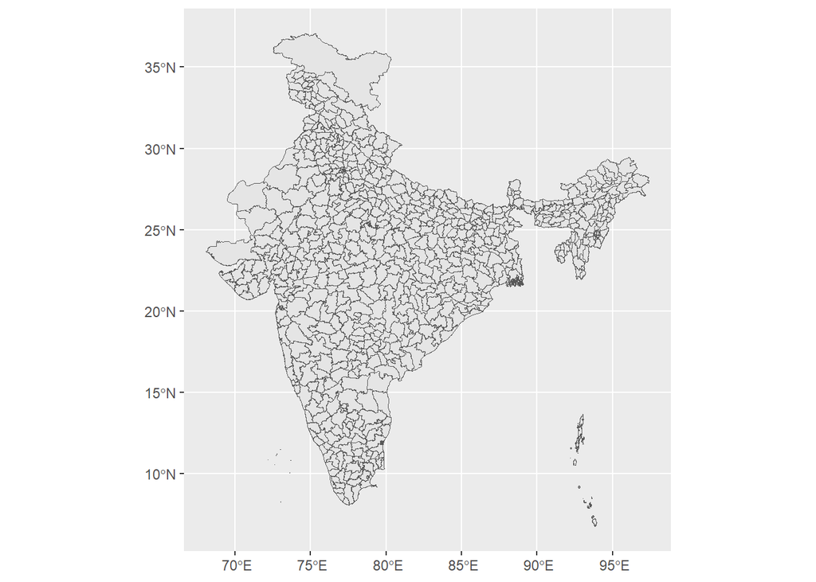

```r
india_district_sf |>
  ggplot() +
  geom_sf()
```

## Clustering of districts with high proportions of stunting (NFHS-4)

### GLOBAL CLUSTERING

Let us check for global clustering using `spdep` package

**Filter data for stunting indicator**

```r
stunting_df <- malnutrition_df |>
  filter(indicator == "stunting")
```

**Join spatial data with stunting data**

```r
stunting_sf <- india_district_sf |>
  left_join(stunting_df)
```

##### STEP ONE: Define neighboring polygons

###### Define the neighbors using the Queen contiguity criterion

```r
nb <- poly2nb(stunting_sf, queen=TRUE)
```

##### STEP TWO: Assign weights to the neighbors

```r
lw <- nb2listw(nb, style="W", zero.policy=TRUE)
```

##### STEP THREE: Compute the (weighted) neighbor mean values

###### Estimate the spatial lag for each district

```r
stunting_sf <- stunting_sf |>
  mutate(spatial_lag = lag.listw(lw, stunting_sf$nfhs4))
```

##### STEP FOUR: Plot Moran’s Scatter Plot

###### Moran’s Scatter Plot shows the relationship between stunting and its spatial lag

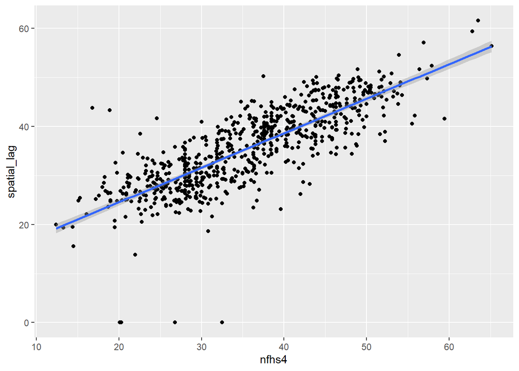

```r
stunting_sf |>
  ggplot(aes(x = nfhs4, y = spatial_lag)) +
  geom_point() +
  geom_smooth(method = "lm")
```

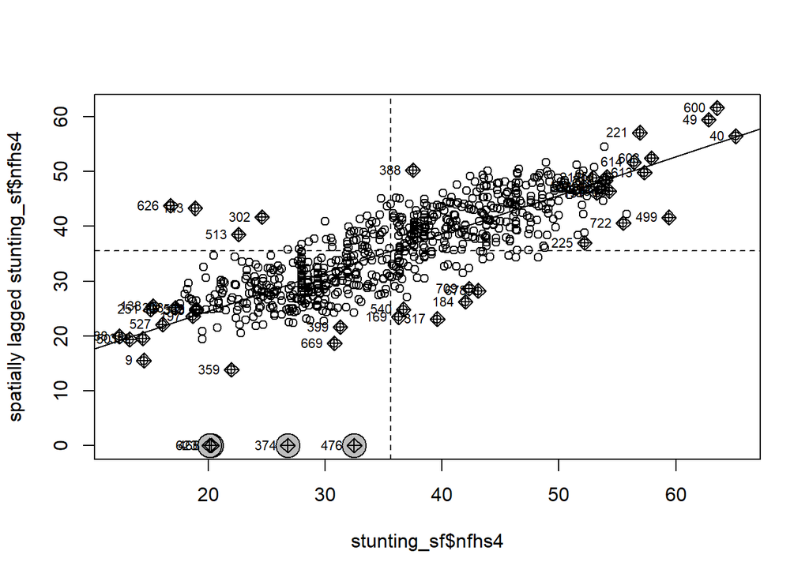

```r
spdep::moran.plot(stunting_sf$nfhs4, lw)
```

##### OLS Regression to estimate the slope of the Moran’s Scatter Plot

```r
ols_model <- lm(spatial_lag ~ nfhs4, data = stunting_sf)
coef(ols_model)[2]
```

```
    nfhs4
0.7046616
```

##### STEP FIVE: Compute the Moran’s I statistic

###### Moran’s I statistic measures spatial autocorrelation

```r
moran(stunting_sf$nfhs4, lw, length(nb), Szero(lw))
```

```
$I
[1] 0.6848853

$K
[1] 2.443471
```

##### STEP SIX: Perform a Hypothesis Test

###### Test the hypothesis that stunting is randomly distributed across districts

###### 6a: ANALYTICAL Method

###### Perform Moran’s I test using the analytical method

```r
moran.test(stunting_sf$nfhs4, lw, alternative="greater")
```

```
    Moran I test under randomisation

data:  stunting_sf$nfhs4
weights: lw
n reduced by no-neighbour observations

Moran I statistic standard deviate = 29.494, p-value < 2.2e-16
alternative hypothesis: greater
sample estimates:
Moran I statistic       Expectation          Variance
     0.6811118323     -0.0013869626      0.0005354613
```

###### 6b: MONTE CARLO Method

Run Monte Carlo simulation to test Moran’s I statistic

```r
set.seed(1234)
mc_moran <- moran.mc(stunting_sf$nfhs4, lw, nsim=9999, alternative="greater")
```

###### 6c: Plot the results

Plot the null distribution of Moran’s I values

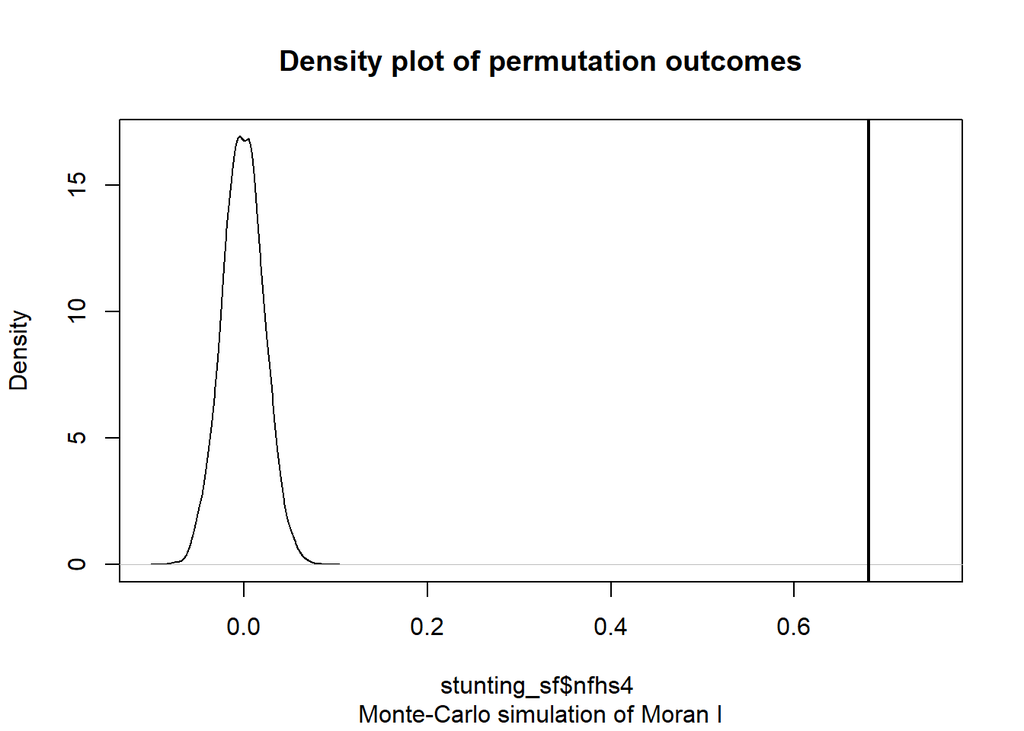

```r
plot(mc_moran)
```

Interpretation: The observed statistic (0.68111) is significantly higher than expected, indicating clustering.

###### 6d: Display the resulting statistics

Print the results of the Monte Carlo simulation

```r
mc_moran
```

```
    Monte-Carlo simulation of Moran I

data:  stunting_sf$nfhs4
weights: lw
number of simulations + 1: 10000

statistic = 0.68111, observed rank = 10000, p-value = 1e-04
alternative hypothesis: greater
```

### LOCAL CLUSTERING

##### Load necessary libraries for local clustering

```r
library(rgeoda)  # For local spatial analysis
```

##### STEP ONE: Create Spatial Weights

Create a spatial weights object using Queen contiguity

```r
queen_w <- queen_weights(stunting_sf)
```

##### STEP TWO: Perform Local Moran’s I Analysis

Compute Local Moran’s I statistics for stunting data

```r
lisa <- local_moran(queen_w, stunting_sf["nfhs4"])
```

Define color schemes for visualization based on Local Moran’s I results

```r
lisa_colors <- lisa_colors(lisa)
```

Define labels and clusters from Local Moran’s I results

```r
lisa_labels <- lisa_labels(lisa)
lisa_clusters <- lisa_clusters(lisa)
lisa_pvals <- lisa_pvalues(lisa)
lisa_vals <- lisa_values(lisa)
```

Create factor labels for clustering based on Local Moran’s I results

```r
lisa_labs <- factor(lisa_clusters, levels = 0:(length(lisa$labels)-1), labels = lisa$labels)
```

Add Local Moran’s I results to the spatial data

```r
clustering_sf <- stunting_sf |>  bind_cols(lisa_clusters = lisa_clusters,
                                           lisa_labs = lisa_labs,
                                           lisa_pvals = lisa_pvals,
                                           lisa_vals = lisa_vals)
```

##### STEP THREE: Categorize P-values

Categorize p-values for plotting significance

```r
clustering_sf <- clustering_sf |>
  mutate(lisa_pvals_cat = case_when(
    lisa_pvals <= 0.001 ~ "p <= 0.001",
    lisa_pvals <= 0.01 ~ "p <= 0.01",
    lisa_pvals <= 0.05 ~ "p <= 0.05",
    TRUE ~ "Not Significant",
    is.na(lisa_pvals) ~ NA_character_
  ))
```

Define colors for p-value categories

```r
pval_colors <- c("#eeeeee", "#1b7837", "#a6dba0", "#d9f0d3")
```

##### STEP FOUR: Create Plots

Create plot showing local clustering results

```r
p_hs <- clustering_sf  |>
  ggplot() +
  geom_sf(aes(fill = lisa_labs), lwd=0.2) +
  scale_fill_manual(name = "Clustering", values = lisa_colors) +
  theme_bw()
```

Create plot showing p-value categories

```r
p_pval <- clustering_sf  |>
  ggplot() +
  geom_sf(aes(fill = lisa_pvals_cat), lwd=0.2) +
  scale_fill_manual(name = "Local Moran's P Value", values = pval_colors) +
  theme_bw()
```

##### STEP FIVE: Combine the Plots

Combine the two plots into one figure for comparison

```r
p_stunting <- (p_hs + p_pval) +
  plot_layout(ncol = 2, guides = "collect") +
  plot_annotation(title = "Spatial Clustering of Stunting (%) among Under-5 Children in India",
                  caption = "Data Source: National Family Health Survey (NFHS) \nhttps://rchiips.org/nfhs/",
                  theme = theme(plot.title = element_text(hjust = 0.5, size = 20)))
```

Display the combined plot

```r
p_stunting
```

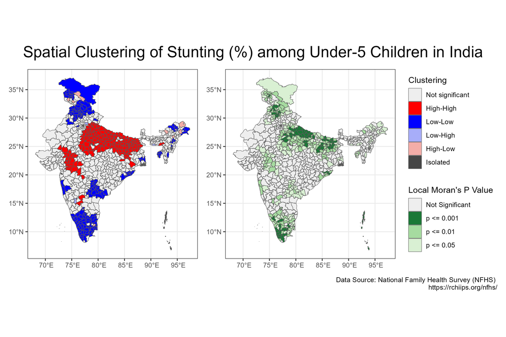

Save the final plot to a file

```r
ggsave(here("plots", "clustering_stunting_plot.png"), width = 9, height = 6)
```

#### Exercise

Can you try it for the rest of the indicators?